# act_report

## Act_report @WeRateDogs Data wrangling Project

*This is a Notebook by Babatunde Akeredolu*

This is a summary report of the analysis and visualizations of the Data Wrangling project of @WeRateDogs twitter archive. The insights from this project are:

1. The most common dog stages are pupper, doggo and puppo
2. The top three dogs with most average retweets are Stephan, Duddles and Jamesy
3. The top three dogs with most average likes are Stephan, Jamesy and Duddles
4. There is a linear relationship between no of retweets and no of likes.

```python
from IPython.display import Image #to embed image
```

##### Insight 1: The most common dog stages are pupper, doggo and puppo

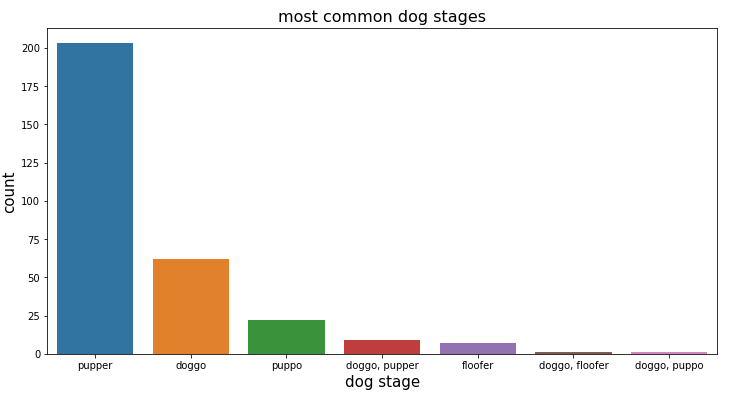

```python
Image("image1.png")
```

- As we can see from the above image, the most dog breeds are pupper, doggo and puppo. Others are doggo, pupper; doggo, floofer and doggo, puppo.
- The occurrence of pupper dog breed is very high compared to other dog breeds.

#### Insight 2: The top three dogs with most average retweets are Stephan, Duddles and Jamesy

#### Insight 3: The top three dogs with most average likes are Stephan, Jamesy and Duddles

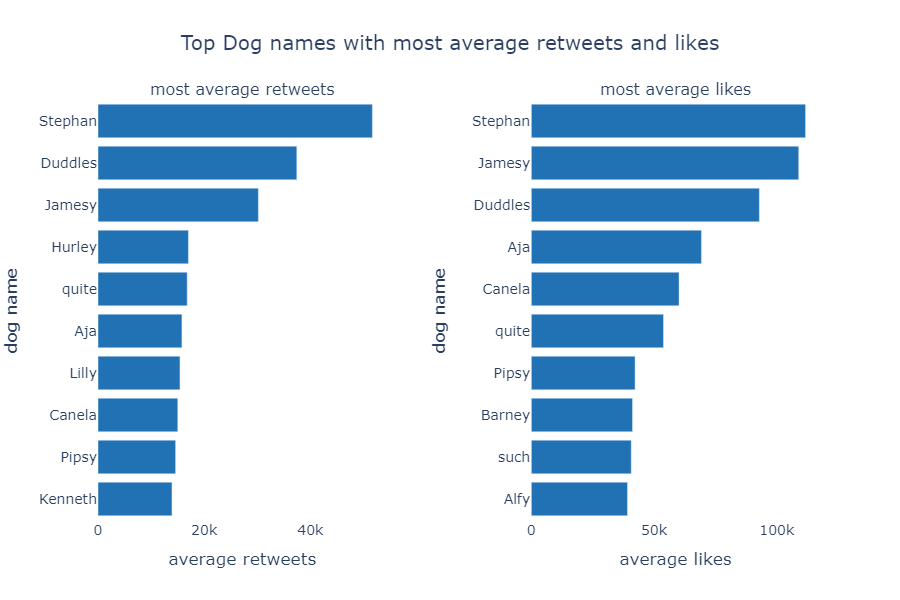

```python
Image("image3.png")
```

- The chart above shows the dogs with the most average retweets and average likes '
- Stephen, Duddles and Jamesy are the top three in the average retweets chart.
- Stephen, Jamesy and Duddles are also the top three in the average likes chart.

#### Insight 4: There is a linear relationship between no of retweets and no of likes.

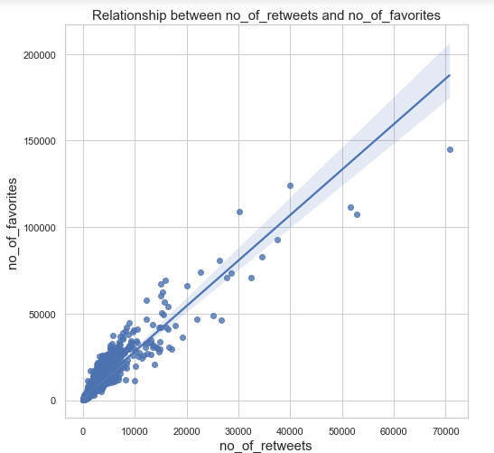

```python
Image("image4.png")
```

- The chart above shows there is a linear relationship between the no of retweets in a post and the no of likes on the same post. This means that the more the retweets, the more the likes.
- This supports our findings in the average retweets and likes charts as the dog with the most retweets are also the ones with the most likes.

#### some images of the tweet

##### Jamesy

[figure not shown]

```python
Image("image5.png")
```

##### Finley

[figure not shown]

```python
Image("image6.png")
```